## Introduction

Using devices such as *Jawbone Up*, *Nike FuelBand*, and *Fitbit* it is now possible to collect a large amount of data about personal activity relatively inexpensively. These type of devices are part of the quantified self movement – a group of enthusiasts who take measurements about themselves regularly to improve their health, to find patterns in their behavior, or because they are tech geeks. One thing that people regularly do is quantify how *much* of a particular activity they do, but they rarely quantify *how well they do it*. In this project, your goal will be to use data from accelerometers on the belt, forearm, arm, and dumbell of 6 participants. They were asked to perform barbell lifts correctly and incorrectly in 5 different ways. More information is available from the website here: http://web.archive.org/web/20161224072740/http:/groupware.les.inf.puc-rio.br/har (see the section on the Weight Lifting Exercise Dataset).

## Load required libraries

```r
library(knitr)
library(caret)
```

```r
library(rpart)
library(rpart.plot)
library(rattle)
library(randomForest)
library(corrplot)
library(e1071)
```

## Define URLs and file names for training and testing datasets

```r
trainURL <- "https://d396qusza40orc.cloudfront.net/predmachlearn/pml-training.csv"
testURL <- "https://d396qusza40orc.cloudfront.net/predmachlearn/pml-testing.csv"
trainFile <- "pml-traininig.csv"
testFile <- "pml-testing.csv"
```

## Download training and testing datasets if they don’t exist locally

```r
if (!file.exists(trainFile)) {
  download.file(trainURL, destfile = trainFile)
}

if (!file.exists(testFile)) {
  download.file(testURL, destfile = testFile)
}
```

## Read in the training and testing datasets

```r
training <- read.csv(trainFile)

testing <- read.csv(testFile)
```

## Create a partition of the training dataset for model evaluation

```r
trainingPartition <- createDataPartition(training$classe, p = 0.7, list = FALSE)

trainSet <- training[trainingPartition, ]

validationSet <- training[-trainingPartition, ]
```

## Data preprocessing: Remove certain types of variables

### Step 1: Identify near-zero variance (NZV) variables in the training set

```r
NZV <- nearZeroVar(trainSet)
```

### Step 2: Remove near-zero variance variables from both training and validation sets

```r
trainSet <- trainSet[, -NZV]
validationSet <- validationSet[, -NZV]
```

### Step 3: Calculate the proportion of missing values for each variable in the training set

```r
na <- sapply(trainSet, function(x) mean(is.na(x))) > 0.95
```

### Step 4: Remove variables with more than 95% missing values from both sets

```r
trainSet <- trainSet[, na == FALSE]

validationSet <- validationSet[, na == FALSE]
```

### Step 5: Remove the first five columns (variables) from both sets

```r
trainSet <- trainSet[, -(1:5)]

validationSet <- validationSet[, -(1:5)]
```

## Create a correlation plot for exploratory data analysis

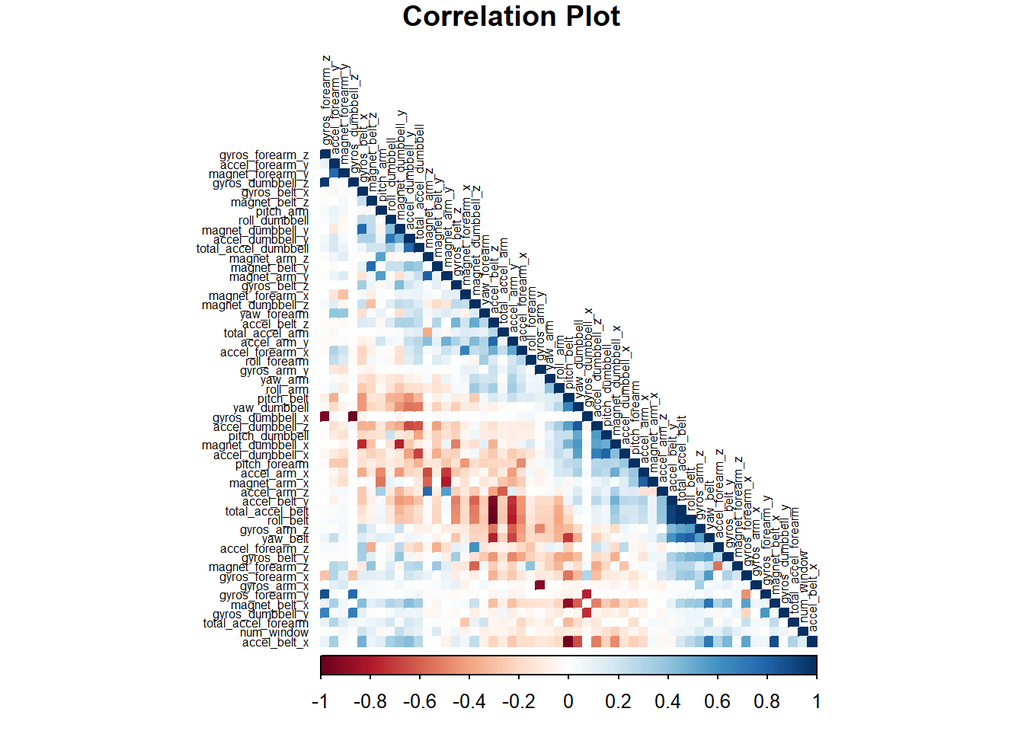

```r
plotCorrelation <- cor(trainSet[, -54])

corrplot(plotCorrelation, method = "color", order = "AOE", type = "lower",
         tl.cex = 0.5, tl.col = rgb(0, 0, 0), title = "Correlation Plot", mar = c(0, 0, 1, 0))
```

## Set a seed for reproducibility

```r
set.seed(12345)
```

## Create a random forest model

```r
controlRF <- trainControl(method = "cv", number = 3, verboseIter = FALSE)

modelRF <- train(classe ~ ., data = trainSet, method = "rf", trControl = controlRF)

modelRF$finalModel
```

```
##
## Call:
##  randomForest(x = x, y = y, mtry = param$mtry)
##                Type of random forest: classification
##                      Number of trees: 500
## No. of variables tried at each split: 27
##
##         OOB estimate of  error rate: 0.28%
## Confusion matrix:
##      A    B    C    D    E  class.error
## A 3904    1    0    0    1 0.0005120328
## B    9 2645    3    1    0 0.0048908954
## C    0    7 2389    0    0 0.0029215359
## D    0    0    6 2245    1 0.0031083481
## E    0    0    0    9 2516 0.0035643564
```

## Predict using the validation dataset and evaluate the random forest model

```r
predictRF <- predict(modelRF, newdata = validationSet)

confusionMatrixRF <- confusionMatrix(predictRF, as.factor(validationSet$classe))

confusionMatrixRF
```

```
## Confusion Matrix and Statistics
##
##           Reference
## Prediction    A    B    C    D    E
##          A 1674    5    0    0    0
##          B    0 1131    4    0    0
##          C    0    3 1022    6    0
##          D    0    0    0  958    6
##          E    0    0    0    0 1076
##
## Overall Statistics
##
##                Accuracy : 0.9959
##                  95% CI : (0.9939, 0.9974)
##     No Information Rate : 0.2845
##     P-Value [Acc > NIR] : < 2.2e-16
##
##                   Kappa : 0.9948
##
##  Mcnemar's Test P-Value : NA
##
## Statistics by Class:
##
##                      Class: A Class: B Class: C Class: D Class: E
## Sensitivity            1.0000   0.9930   0.9961   0.9938   0.9945
## Specificity            0.9988   0.9992   0.9981   0.9988   1.0000
## Pos Pred Value         0.9970   0.9965   0.9913   0.9938   1.0000
## Neg Pred Value         1.0000   0.9983   0.9992   0.9988   0.9988
## Prevalence             0.2845   0.1935   0.1743   0.1638   0.1839
## Detection Rate         0.2845   0.1922   0.1737   0.1628   0.1828
## Detection Prevalence   0.2853   0.1929   0.1752   0.1638   0.1828
## Balanced Accuracy      0.9994   0.9961   0.9971   0.9963   0.9972
```

## Plot results

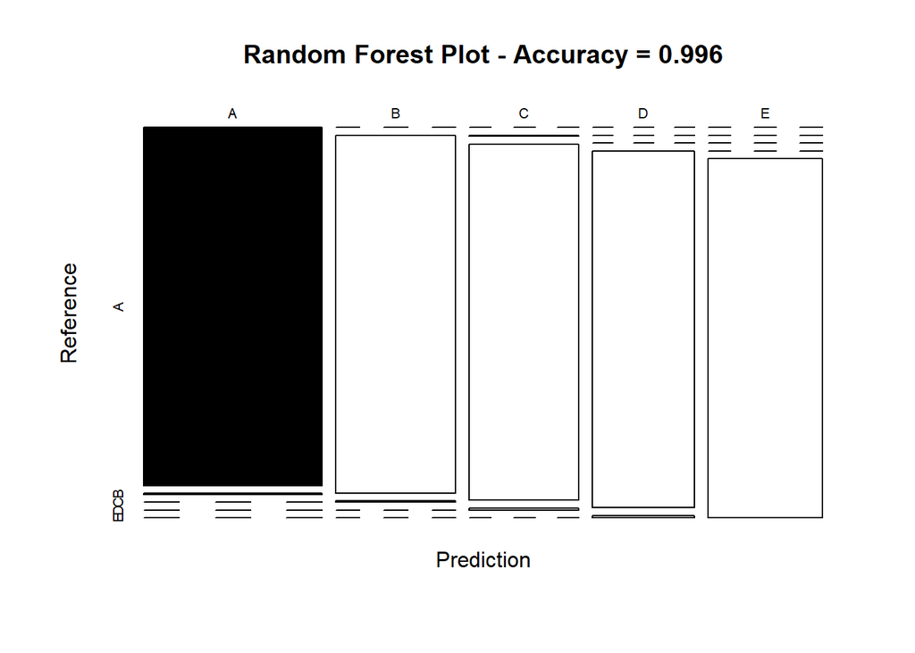

```r
plot(confusionMatrixRF$table, col = confusionMatrixRF$byClass,
     main = paste("Random Forest Plot - Accuracy =", round(confusionMatrixRF$overall['Accuracy'], 3)))
```

## Set a seed for reproducibility

```r
set.seed(12345)
```

## Create a decision tree model

```r
modelDT <- rpart(classe ~ ., data = trainSet, method = "class")
```

## Predict using the validation dataset and evaluate the decision tree model

```r
predictDT <- predict(modelDT, newdata = validationSet, type = "class")

confusionMatrixDT <- confusionMatrix(predictDT, as.factor(validationSet$classe))

confusionMatrixDT
```

```
## Confusion Matrix and Statistics
##
##           Reference
## Prediction    A    B    C    D    E
##          A 1429   92    2    9    7
##          B  105  855   72   79   60
##          C   23   69  848   37    6
##          D   98   41   94  766   68
##          E   19   82   10   73  941
##
## Overall Statistics
##
##                Accuracy : 0.8223
##                  95% CI : (0.8122, 0.832)
##     No Information Rate : 0.2845
##     P-Value [Acc > NIR] : < 2.2e-16
##
##                   Kappa : 0.7759
##
##  Mcnemar's Test P-Value : < 2.2e-16
##
## Statistics by Class:
##
##                      Class: A Class: B Class: C Class: D Class: E
## Sensitivity            0.8536   0.7507   0.8265   0.7946   0.8697
## Specificity            0.9739   0.9334   0.9722   0.9388   0.9617
## Pos Pred Value         0.9285   0.7301   0.8627   0.7179   0.8364
## Neg Pred Value         0.9436   0.9398   0.9637   0.9589   0.9704
## Prevalence             0.2845   0.1935   0.1743   0.1638   0.1839
## Detection Rate         0.2428   0.1453   0.1441   0.1302   0.1599
## Detection Prevalence   0.2615   0.1990   0.1670   0.1813   0.1912
## Balanced Accuracy      0.9138   0.8420   0.8994   0.8667   0.9157
```

## Plot results

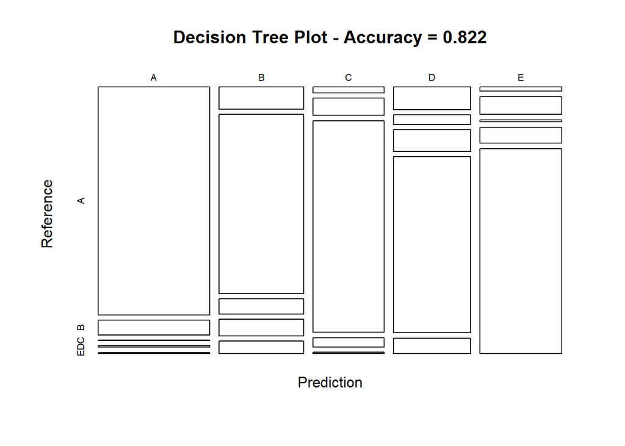

```r
plot(confusionMatrixDT$table, col = confusionMatrixDT$byClass,
     main = paste("Decision Tree Plot - Accuracy =", round(confusionMatrixDT$overall['Accuracy'], 3)))
```

## Set a seed for reproducibility

```r
set.seed(12345)
```

## Create a generalized boosted model

```r
controlGBM <- trainControl(method = "repeatedcv", number = 5, repeats = 1)

modelGBM <- train(classe ~ ., data = trainSet, method = "gbm", trControl = controlGBM, verbose = FALSE)

modelGBM$finalModel
```

```
## A gradient boosted model with multinomial loss function.
## 150 iterations were performed.
## There were 53 predictors of which 53 had non-zero influence.
```

## Predict using the validation dataset and evaluate the generalized boosted model

```r
predictGBM <- predict(modelGBM, newdata = validationSet)

confusionMatrixGBM <- confusionMatrix(predictGBM, as.factor(validationSet$classe))

confusionMatrixGBM
```

```
## Confusion Matrix and Statistics
##
##           Reference
## Prediction    A    B    C    D    E
##          A 1670   10    0    3    0
##          B    2 1107   15    4    2
##          C    0   22 1011   17    2
##          D    0    0    0  938   15
##          E    2    0    0    2 1063
##
## Overall Statistics
##
##                Accuracy : 0.9837
##                  95% CI : (0.9801, 0.9868)
##     No Information Rate : 0.2845
##     P-Value [Acc > NIR] : < 2.2e-16
##
##                   Kappa : 0.9794
##
##  Mcnemar's Test P-Value : NA
##
## Statistics by Class:
##
##                      Class: A Class: B Class: C Class: D Class: E
## Sensitivity            0.9976   0.9719   0.9854   0.9730   0.9824
## Specificity            0.9969   0.9952   0.9916   0.9970   0.9992
## Pos Pred Value         0.9923   0.9796   0.9610   0.9843   0.9963
## Neg Pred Value         0.9990   0.9933   0.9969   0.9947   0.9961
## Prevalence             0.2845   0.1935   0.1743   0.1638   0.1839
## Detection Rate         0.2838   0.1881   0.1718   0.1594   0.1806
## Detection Prevalence   0.2860   0.1920   0.1788   0.1619   0.1813
## Balanced Accuracy      0.9973   0.9835   0.9885   0.9850   0.9908
```

## Plot results

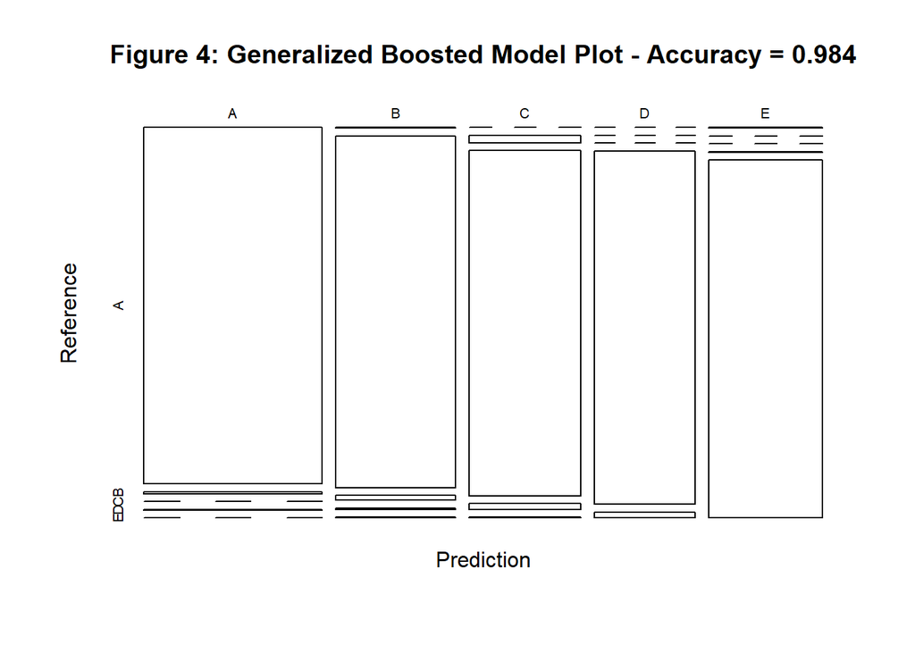

```r
plot(confusionMatrixGBM$table, col = confusionMatrixGBM$byClass,
     main = paste("Figure 4: Generalized Boosted Model Plot - Accuracy =", round(confusionMatrixGBM$overall['Accuracy'], 3)))
```

## Predict using the random forest model on the testing dataset

```r
predict <- predict(modelRF, newdata = testing)

predict
```

```
##  [1] B A B A A E D B A A B C B A E E A B B B
## Levels: A B C D E
```